# Polytomous Logistic Regression Model to Predict Region in County Crime Dataset

Amir Idris

```r
if (!require("dplyr")){
  install.packages("dplyr")
}
if (!require("nnet")){
  install.packages("nnet")
}
if (!require("ggplot2")){
  install.packages("ggplot2")
}
if (!require("formattable")){
  install.packages("formattable")
}
library(dplyr)
library(nnet)
library(formattable)
library(ggplot2)
```

First, let’s load the data.

```r
crime <- read.table("../data/APPENC02.txt", sep="", header=FALSE)
UNI <- 2244
set.seed(UNI)
index <- sample(c(1:440))
crime <- crime[index[1:250],]

# Rename column names to reflect meaning
column.names <- c("Id", "County Name", "State", "Land Area", "Total Pop.", "Percent of Pop. Age 18-34", "Percent of Pop. Age >= 65", "Num of Active Physicians", "Num of Hospital Beds", "Total Serious Crimes", "Percent High School Graduates", "Percent Bachelor's Degree", "Percent Below Poverty Level", "Percent Unemployment", "Per Capita Income", "Total personal income", "Geographic Region")

colnames(crime) <- column.names

# Add crimes per person as column
crimes_per_person <- crime$`Total Serious Crimes`/crime$`Total Pop.`
crime <- as.data.frame(cbind(crime, crimes_per_person))

# Add hospital beds per person as column
beds_per_person <- crime$`Num of Hospital Beds`/crime$`Total Pop.`
crime <- as.data.frame(cbind(crime, beds_per_person))

crime$`Geographic Region` <- as.factor(crime$`Geographic Region`) #Ensure our outcome variable is treated as a factor variable
with(crime, levels(`Geographic Region`))
```

```
[1] "1" "2" "3" "4"
```

```r
head(crime)
```

|  | Id | County Name | State | Land Area | Total Pop. | Percent of Pop. Age 18-34 | Percent of Pop. Age >= 65 | Num of Active Physicians | Num of Hospital Beds | Total Serious Crimes | Percent High School Graduates | Percent Bachelor's Degree | Percent Below Poverty Level | Percent Unemployment | Per Capita Income | Total personal income | Geographic Region | crimes_per_person | beds_per_person |
| --- | --- | --- | --- | --- | --- | --- | --- | --- | --- | --- | --- | --- | --- | --- | --- | --- | --- | --- | --- |
| 144 | 144 | Guilford | NC | 650 | 347420 | 30.4 | 11.9 | 676 | 1188 | 28212 | 76.1 | 24.8 | 7.3 | 5.4 | 20349 | 7070 | 3 | 0.08120431 | 0.003419492 |
| 60 | 60 | Duval | FL | 774 | 672971 | 30.7 | 10.7 | 1538 | 2623 | 68586 | 76.9 | 18.4 | 9.8 | 6.6 | 17662 | 11886 | 3 | 0.10191524 | 0.003897642 |
| 110 | 110 | Jefferson | CO | 772 | 438430 | 26.9 | 8.0 | 551 | 298 | 23453 | 89.8 | 30.7 | 4.1 | 4.1 | 20997 | 9206 | 4 | 0.05349315 | 0.000679698 |
| 166 | 166 | Richland | SC | 757 | 285720 | 34.7 | 9.5 | 999 | 1207 | 24101 | 79.4 | 28.0 | 10.1 | 4.6 | 17137 | 4896 | 3 | 0.08435181 | 0.004224416 |
| 181 | 181 | Adams | CO | 1192 | 265038 | 29.6 | 7.6 | 439 | 318 | 19369 | 78.8 | 13.0 | 8.8 | 5.0 | 16116 | 4271 | 4 | 0.07308009 | 0.001199828 |
| 162 | 162 | Butler | OH | 467 | 291479 | 29.9 | 10.2 | 308 | 878 | 13850 | 76.0 | 18.7 | 7.6 | 6.6 | 16750 | 4882 | 2 | 0.04751629 | 0.003012224 |

Summary of data

```r
summary(crime)
```

[output not shown]

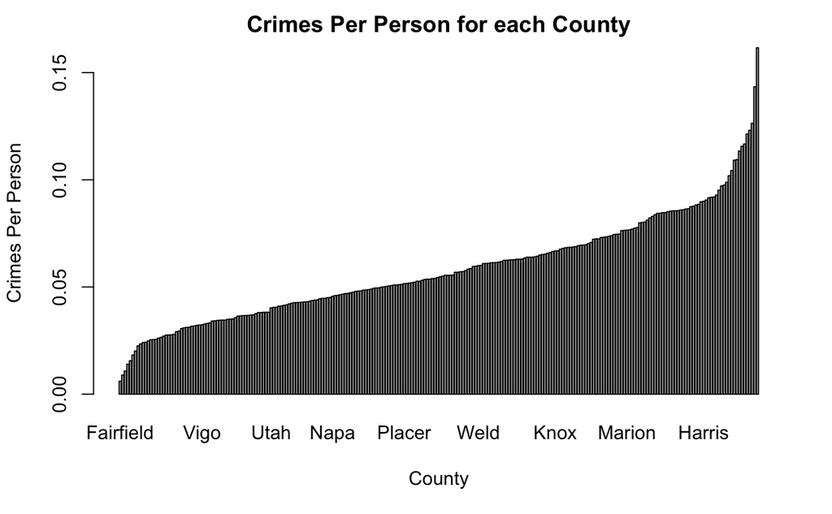

```r
# Plot crime per person
crime_pop <- crime[order(crime$crimes_per_person), ]

barplot(crime_pop$crimes_per_person, names.arg = crime_pop$`County Name`, xlab = "County", ylab = "Crimes Per Person", main = "Crimes Per Person for each County")
```

Now we can see we no longer need to log-transform total crime and population

**Significant** * Land area: larger in West * Number of hospital beds per capita: lower in west, makes sense * Number of serious crimes per capita: higher in south, Lowest in NE * Percent high school graduates: lowest in south * Percent below poverty level: highest in south and west, lowest in NE * Per capita income: highest in NE * Personal income: “ **Almost significant** * Percent unemployment

Next, lets split the data into training and testing, and 80/20 split.

```r
# Credit to https://stackoverflow.com/questions/17200114/how-to-split-data-into-training-testing-sets-using-sample-function
train_index <- sample.int(n = nrow(crime), size = floor(.80*nrow(crime)), replace = F)
train_crime <- crime[train_index, ]
test_crime  <- crime[-train_index, ]

print(dim(train_crime))
```

```
[1] 200  19
```

```r
print(dim(test_crime))
```

```
[1] 50 19
```

Rename output categories

```r
levels(crime$`Geographic Region`) <- c("Northeast", "North Central", "South", "West")
```

Now let’s fit our Logistic Regression Model, log-transforming the variables that are exponentially-distributed.

```r
mod0 <- multinom(`Geographic Region` ~ log(`Land Area`) + beds_per_person + crimes_per_person + `Percent High School Graduates` + `Percent Below Poverty Level` + `Per Capita Income` + `Percent Unemployment`, data = train_crime)
#summary(mod0)
coefs <- as.data.frame(summary(mod0)$coefficients)
std_errs <- as.data.frame(round(summary(mod0)$standard.errors, 7))
formattable(coefs, align = c("l", rep("r", NCOL(coefs) - 1)))
```

|  | (Intercept) | log(`Land Area`) | beds_per_person | crimes_per_person | `Percent High School Graduates` | `Percent Below Poverty Level` | `Per Capita Income` | `Percent Unemployment` |
| --- | --- | --- | --- | --- | --- | --- | --- | --- |
| 2 | -21.627274 | 0.2717270 | 104.82762 | 61.53390 | 0.27317571 | 0.2131002 | -0.0002349493 | -0.1819511 |
| 3 | -4.113617 | 0.9307716 | -104.07669 | 106.30490 | 0.06722219 | 0.1206909 | -0.0004245416 | -0.6805669 |
| 4 | -62.461336 | 3.6531172 | -34.17525 | 74.97167 | 0.43718129 | 0.4088358 | -0.0001169030 | -0.1650991 |

```r
formattable(std_errs, align = c("l", rep("r", NCOL(std_errs) - 1)))
```

|  | (Intercept) | log(`Land Area`) | beds_per_person | crimes_per_person | `Percent High School Graduates` | `Percent Below Poverty Level` | `Per Capita Income` | `Percent Unemployment` |
| --- | --- | --- | --- | --- | --- | --- | --- | --- |
| 2 | 0.0004228 | 0.0026393 | 8.3e-06 | 7.37e-05 | 0.0194222 | 0.0264594 | 7.50e-05 | 0.0101776 |
| 3 | 0.0004099 | 0.0033124 | 6.0e-06 | 5.27e-05 | 0.0231164 | 0.0229812 | 9.55e-05 | 0.0087982 |
| 4 | 0.0004523 | 0.0041619 | 2.9e-06 | 5.03e-05 | 0.0263245 | 0.0265271 | 1.06e-04 | 0.0127627 |

Let’s see if we can judge the accuracy of this model on the training and testing datasets

```r
# Credit to https://datasciencebeginners.com/2018/12/20/multinomial-logistic-regression-using-r/

# Predicting the values for train dataset
train_crime$predicted <- predict(mod0, newdata = train_crime, "class")

# Building classification table
ctable_train <- table(train_crime$`Geographic Region`, train_crime$predicted)

# Calculating accuracy - sum of diagonal elements divided by total obs
train_acc <- round((sum(diag(ctable_train))/sum(ctable_train))*100,4)


# Predicting the values for test dataset
test_crime$predicted <- predict(mod0, newdata = test_crime, "class")

# Building classification table
ctable_test <- table(test_crime$`Geographic Region`, test_crime$predicted)

# Calculating accuracy - sum of diagonal elements divided by total obs
test_acc <- round((sum(diag(ctable_test))/sum(ctable_test))*100,4)

print(paste("Training Accuracy: ", train_acc, "%", sep=""))
```

```
[1] "Training Accuracy: 65.5%"
```

```r
print(paste("Testing Accuracy: ", test_acc, "%", sep=""))
```

```
[1] "Testing Accuracy: 66%"
```

While our accuracy is not incredibly high, we are performing much better than random, which with the 4 unbalanced classes we have, would not perform much better than 35%

Histogram of output categories

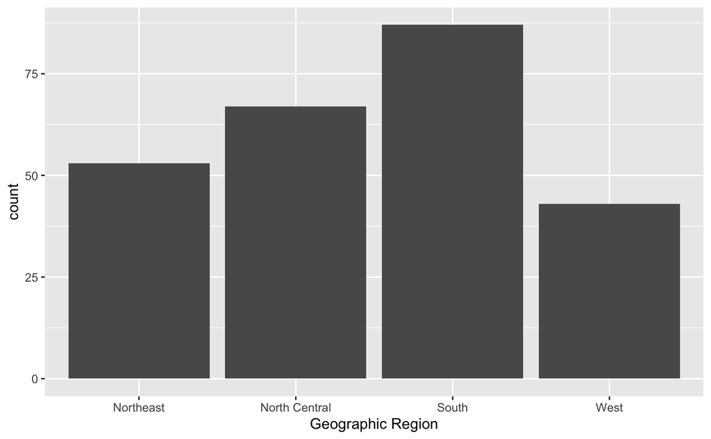

```r
ggplot(crime, aes(x = `Geographic Region`)) +
    geom_bar()
```

```r
# Get counts by region
freq_table <- crime %>% group_by(`Geographic Region`) %>% tally()
freq_table$n <- freq_table$n/(count(crime)[1,1])
freq_table
```

| Geographic Region | n |
| --- | --- |
| Northeast | 0.212 |
| North Central | 0.268 |
| South | 0.348 |
| West | 0.172 |

Let’s see which of our coefficients are significant.

```r
# Credit to https://stats.idre.ucla.edu/r/dae/multinomial-logistic-regression/

z <- summary(mod0)$coefficients/summary(mod0)$standard.errors
p <- as.data.frame((1 - pnorm(abs(z), 0, 1)) * 2) #testing if B_i = 0 vs. B_i /= 0
z <- as.data.frame(z)

formattable(z, align = c("l", rep("r", NCOL(z) - 1)))
```

|  | (Intercept) | log(`Land Area`) | beds_per_person | crimes_per_person | `Percent High School Graduates` | `Percent Below Poverty Level` | `Per Capita Income` | `Percent Unemployment` |
| --- | --- | --- | --- | --- | --- | --- | --- | --- |
| 2 | -51153.19 | 102.9561 | 12689615 | 834919.5 | 14.065120 | 8.053854 | -3.133742 | -17.87756 |
| 3 | -10035.32 | 280.9985 | -17488819 | 2017520.1 | 2.907989 | 5.251714 | -4.444593 | -77.35336 |
| 4 | -138111.53 | 877.7597 | -11722491 | 1490780.2 | 16.607375 | 15.411978 | -1.103191 | -12.93608 |

```r
formattable(p, align = c("l", rep("r", NCOL(p) - 1)))
```

|  | (Intercept) | log(`Land Area`) | beds_per_person | crimes_per_person | `Percent High School Graduates` | `Percent Below Poverty Level` | `Per Capita Income` | `Percent Unemployment` |
| --- | --- | --- | --- | --- | --- | --- | --- | --- |
| 2 | 0 | 0 | 0 | 0 | 0.000000000 | 8.881784e-16 | 1.725924e-03 | 0 |
| 3 | 0 | 0 | 0 | 0 | 0.003637617 | 1.506900e-07 | 8.805827e-06 | 0 |
| 4 | 0 | 0 | 0 | 0 | 0.000000000 | 0.000000e+00 | 2.699443e-01 | 0 |

We can see that there is only one coefficients that is not significant at an alpha-level of 0.05: per capita income for level 4. Since these coefficients are in comparison to our baseline level of the Northeast, then this tells us that per capita income does not differ significantly between the west and the northeast in our data according to our model.

Last thing we should do is view the exponentiated coefficients, and see what we can interpret from them:

```r
exp_coefs <- exp(summary(mod0)$coefficients)
exp_coefs
```

```
   (Intercept) log(`Land Area`) beds_per_person crimes_per_person `Percent High School Graduates` `Percent Below Poverty Level`
2 4.049434e-10         1.312229    3.357821e+45      5.294625e+26                        1.314131                      1.237509
3 1.634854e-02         2.536466    6.310589e-46      1.471070e+46                        1.069533                      1.128276
4 7.471130e-28        38.594787    1.438394e-15      3.628960e+32                        1.548337                      1.505065
  `Per Capita Income` `Percent Unemployment`
2           0.9997651              0.8336421
3           0.9995755              0.5063299
4           0.9998831              0.8478097
```

This is very interesting to see. Although many of our coefficients were significant, many of there effects are extremely close to 1. As a reminder, the interpretation of a given coefficient Blj is that assuming that a region is either NE or region l, if we increase x_j by 1 and hold all other features fixed, the odds that the outcome is region j increases by a multiplicative factor of B_lj. Therefore, if B_lj is close to 1, the odds will not change by a large amount in response to a change in x_j.

Let’s do some Likelihood ratio tests to gauge the collective relevance of certain variables in our model. First, let’s test a model only using crimes_per_person and beds_per_person vs. using all other variables

```r
mod_red <- multinom(`Geographic Region` ~ crimes_per_person + beds_per_person, data = train_crime)
summary(mod_red)
```

```
Call:
multinom(formula = `Geographic Region` ~ crimes_per_person +
    beds_per_person, data = train_crime)

Coefficients:
  (Intercept) crimes_per_person beds_per_person
2   -2.588809          51.18169        99.57069
3   -4.071160          88.33581       -51.80778
4   -2.542043          54.70369       -82.42937

Std. Errors:
  (Intercept) crimes_per_person beds_per_person
2   0.7039189          14.20250        117.7684
3   0.7626716          14.93088        127.9557
4   0.7675580          15.33059        143.8675

Residual Deviance: 470.3903
AIC: 488.3903
```

```r
#LRT
anova(mod_red, mod0, test="Chisq")
```

| Model | Resid. df | Resid. Dev | Test | Df | LR stat. | Pr(Chi) |
| --- | --- | --- | --- | --- | --- | --- |
| crimes_per_person + beds_per_person | 591 | 470.3903 |  | NA | NA | NA |
| log(`Land Area`) + beds_per_person + crimes_per_person + `Percent High School Graduates` + `Percent Below Poverty Level` + `Per Capita Income` + `Percent Unemployment` | 576 | 324.2999 | 1 vs 2 | 15 | 146.0904 | 0 |

We can see that the full model, according to our test, better fits our data at any reasonable alpha-level. Now, let’s try testing if per capita income has a coefficient of zero in our model.

```r
mod_red <- multinom(`Geographic Region` ~ log(`Land Area`) + crimes_per_person + beds_per_person + `Percent High School Graduates` + `Percent Below Poverty Level` + `Percent Unemployment`, data = train_crime)
summary(mod_red)
```

```
Call:
multinom(formula = `Geographic Region` ~ log(`Land Area`) + crimes_per_person +
    beds_per_person + `Percent High School Graduates` + `Percent Below Poverty Level` +
    `Percent Unemployment`, data = train_crime)

Coefficients:
  (Intercept) log(`Land Area`) crimes_per_person beds_per_person `Percent High School Graduates` `Percent Below Poverty Level`
2  -21.594792        0.4669508          54.77926       106.41421                      0.19460239                     0.3091140
3   -7.433738        1.2108303          92.85728      -119.00207                     -0.02095251                     0.2838537
4  -55.993296        3.7476011          73.89368       -31.12809                      0.32360090                     0.4055777
  `Percent Unemployment`
2             -0.2022023
3             -0.7007076
4             -0.2225114

Std. Errors:
  (Intercept) log(`Land Area`) crimes_per_person beds_per_person `Percent High School Graduates` `Percent Below Poverty Level`
2    6.053461        0.3837335          8.378628       0.2514441                      0.06449402                     0.1199204
3    5.537136        0.4033675          7.501398       0.2299211                      0.05806455                     0.1180083
4   10.458414        0.6302206          9.013999       0.2325939                      0.09827129                     0.1470867
  `Percent Unemployment`
2              0.1556781
3              0.1703650
4              0.2088623

Residual Deviance: 340.7968
AIC: 382.7968
```

```r
#LRT
anova(mod_red, mod0, test="Chisq")
```

| Model | Resid. df | Resid. Dev | Test | Df | LR stat. | Pr(Chi) |
| --- | --- | --- | --- | --- | --- | --- |
| log(`Land Area`) + crimes_per_person + beds_per_person + `Percent High School Graduates` + `Percent Below Poverty Level` + `Percent Unemployment` | 579 | 340.7968 |  | NA | NA | NA |
| log(`Land Area`) + beds_per_person + crimes_per_person + `Percent High School Graduates` + `Percent Below Poverty Level` + `Per Capita Income` + `Percent Unemployment` | 576 | 324.2999 | 1 vs 2 | 3 | 16.4969 | 0.0008967076 |

With an alpha-level of 0.05, we reject the null hypothesis that per capita income has a coefficient of zero in our model. So, we may keep all of these variables in our model, although some seem to add little relative weight to the model decision.